# Homework 02

## Question 1: Training and test error under a fixed design

### a–b. Simulation and theoretical expectations

I generated the design matrix once and then kept it fixed for all 200 simulations. In each simulation I generated a new training response and a new test response, then fit the nested models with 0 through 20 predictors.

**Show the R code**

```r
set.seed(43202)

n <- 100
q <- 20
nsim <- 200

X_all <- matrix(rnorm(n * q), nrow = n, ncol = q)
beta <- 0.4^(sqrt(1:q))
mu <- as.vector(X_all %*% beta)

train_mse <- matrix(NA_real_, nrow = nsim, ncol = q + 1)
test_mse <- matrix(NA_real_, nrow = nsim, ncol = q + 1)

for (r in 1:nsim) {
  y <- mu + rnorm(n)
  y_star <- mu + rnorm(n)

  for (j in 0:q) {
    Xj <- cbind(1, X_all[, seq_len(j), drop = FALSE])
    fit <- lm.fit(Xj, y)
    mu_hat <- as.vector(Xj %*% fit$coefficients)

    train_mse[r, j + 1] <- mean((y - mu_hat)^2)
    test_mse[r, j + 1] <- mean((y_star - mu_hat)^2)
  }
}

j_values <- 0:q
avg_train <- colMeans(train_mse)
avg_test <- colMeans(test_mse)

non_increasing <- apply(
  train_mse,
  1,
  function(z) all(diff(z) <= 1e-10)
)

cat(
  "Runs with non-increasing training MSE:",
  sum(non_increasing), "out of", nsim, "\n"
)
```

```
Runs with non-increasing training MSE: 200 out of 200
```

**Show the R code**

```r
B2 <- numeric(q + 1)

for (j in 0:q) {
  Xj <- cbind(1, X_all[, seq_len(j), drop = FALSE])
  Hj <- Xj %*% solve(crossprod(Xj)) %*% t(Xj)
  bias_vec <- (diag(n) - Hj) %*% mu
  B2[j + 1] <- sum(bias_vec^2)
}

p_j <- j_values + 1

theory_train <- B2 / n + 1 - p_j / n
theory_test <- B2 / n + 1 + p_j / n

result_q1 <- data.frame(
  j = j_values,
  average_train = round(avg_train, 4),
  theoretical_train = round(theory_train, 4),
  average_test = round(avg_test, 4),
  theoretical_test = round(theory_test, 4)
)

result_q1
```

```
    j average_train theoretical_train average_test theoretical_test
1   0        1.3147            1.2974       1.3367           1.3174
2   1        1.1881            1.1763       1.2279           1.2163
3   2        1.0986            1.0872       1.1546           1.1472
4   3        1.0415            1.0319       1.1144           1.1119
5   4        1.0105            1.0022       1.1046           1.1022
6   5        0.9806            0.9750       1.0979           1.0950
7   6        0.9623            0.9547       1.0940           1.0947
8   7        0.9481            0.9395       1.0995           1.0995
9   8        0.9327            0.9243       1.1034           1.1043
10  9        0.9173            0.9105       1.1096           1.1105
11 10        0.9061            0.8992       1.1186           1.1192
12 11        0.8948            0.8878       1.1251           1.1278
13 12        0.8846            0.8764       1.1325           1.1364
14 13        0.8744            0.8640       1.1390           1.1440
15 14        0.8625            0.8524       1.1489           1.1524
16 15        0.8524            0.8419       1.1594           1.1619
17 16        0.8409            0.8315       1.1675           1.1715
18 17        0.8279            0.8209       1.1786           1.1809
19 18        0.8166            0.8106       1.1910           1.1906
20 19        0.8052            0.8002       1.2052           1.2002
21 20        0.7948            0.7900       1.2170           1.2100
```

As expected, the training MSE never increases when another predictor is added. The larger model contains the smaller model, so least squares can always keep the old fit if the new variable does not help.

For each predictor count, I used the following conditional expectations. The parameter count is one more than the predictor count because the intercept is also estimated.

$$\mathbb{E}\!\left(
\operatorname{MSE}_{\mathrm{train},j}
\mid \mathbf X_{\mathrm{all}}
\right)
=
\frac{B_j^2}{n}+1-\frac{p_j}{n}$$

and

$$\mathbb{E}\!\left(
\operatorname{MSE}_{\mathrm{test},j}
\mid \mathbf X_{\mathrm{all}}
\right)
=
\frac{B_j^2}{n}+1+\frac{p_j}{n}.$$

The simulated averages are close to these curves. They do not match exactly because there are only 200 runs, but most of the random fluctuation is averaged out.

### c. One simulation run

**Show the R code**

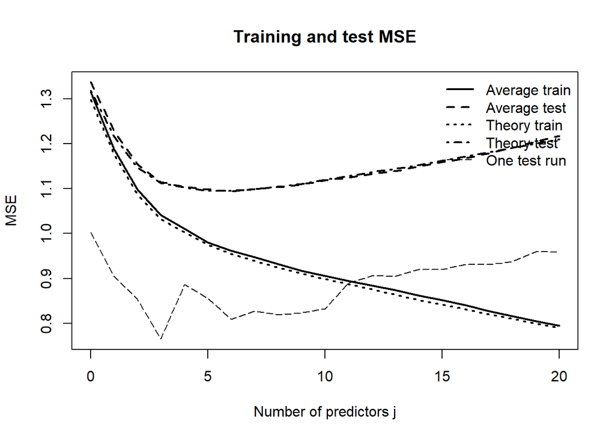

```r
y_range <- range(
  avg_train,
  avg_test,
  theory_train,
  theory_test,
  test_mse[1, ]
)

plot(
  j_values, avg_train,
  type = "l", lwd = 2, lty = 1,
  ylim = y_range,
  xlab = "Number of predictors j",
  ylab = "MSE",
  main = "Training and test MSE"
)
lines(j_values, avg_test, lwd = 2, lty = 2)
lines(j_values, theory_train, lwd = 2, lty = 3)
lines(j_values, theory_test, lwd = 2, lty = 4)
lines(j_values, test_mse[1, ], lwd = 1, lty = 5)

legend(
  "topright",
  legend = c(
    "Average train",
    "Average test",
    "Theory train",
    "Theory test",
    "One test run"
  ),
  lty = 1:5,
  lwd = c(2, 2, 2, 2, 1),
  bty = "n"
)
```

The test curve from one run jumps around much more than the average curve. That is just the random noise from one training sample and one test sample showing up in the result.

There is also a clear difference between training and test error as more predictors are added. Adding variables can reduce omitted-variable bias, but it also adds estimation variance. Training error does not pay the same price for that extra variance, which is why choosing a model only from training MSE would usually favor a model that is too large.

## Question 2: Prediction error at one target point

### a. Theoretical error

At the target point, only coordinates 2 and 5 are nonzero. Therefore,

$$\mu_0
=
\mathbf x_0^{\mathsf T}\boldsymbol\beta
=
0.5+0.5
=
1.$$

**Show the R code**

```r
n <- 100
q <- 6
sigma2 <- 1

X_all_q2 <- outer(
  1:n, 1:q,
  function(i, k) sqrt(2) * cos(pi * k * (i - 0.5) / n)
)

beta_q2 <- rep(0.5, q)
x0 <- c(0, 1, 0, 0, 1, 0)
mu0 <- sum(x0 * beta_q2)

theory_q2 <- numeric(q + 1)

for (j in 0:q) {
  omitted <- if (j < q) (j + 1):q else integer(0)
  included <- seq_len(j)

  bias <- sum(x0[omitted] * beta_q2[omitted])
  variance <- sigma2 / n * (1 + sum(x0[included]^2))

  theory_q2[j + 1] <- bias^2 + variance
}

data.frame(
  j = 0:q,
  theoretical_error = theory_q2
)
```

```
  j theoretical_error
1 0              1.01
2 1              1.01
3 2              0.27
4 3              0.27
5 4              0.27
6 5              0.03
7 6              0.03
```

The theoretical error is 1.01 for 0 or 1 predictor, 0.27 for 2 through 4 predictors, and 0.03 for 5 or 6 predictors. It only changes when predictor 2 or predictor 5 enters because those are the only two nonzero coordinates of the target point.

### b. Simulation

**Show the R code**

```r
set.seed(43203)

nsim <- 200
squared_error <- matrix(NA_real_, nrow = nsim, ncol = q + 1)
mu_vec <- as.vector(X_all_q2 %*% beta_q2)

for (r in 1:nsim) {
  y <- mu_vec + rnorm(n)

  for (j in 0:q) {
    Xj <- cbind(1, X_all_q2[, seq_len(j), drop = FALSE])
    fit <- lm.fit(Xj, y)

    new_x <- c(1, x0[seq_len(j)])
    mu_hat_0 <- sum(new_x * fit$coefficients)

    squared_error[r, j + 1] <- (mu_hat_0 - mu0)^2
  }
}

avg_squared_error <- colMeans(squared_error)

result_q2 <- data.frame(
  j = 0:q,
  simulation_average = round(avg_squared_error, 4),
  theoretical = round(theory_q2, 4)
)

result_q2
```

```
  j simulation_average theoretical
1 0             1.0189        1.01
2 1             1.0189        1.01
3 2             0.2671        0.27
4 3             0.2671        0.27
5 4             0.2671        0.27
6 5             0.0338        0.03
7 6             0.0338        0.03
```

**Show the R code**

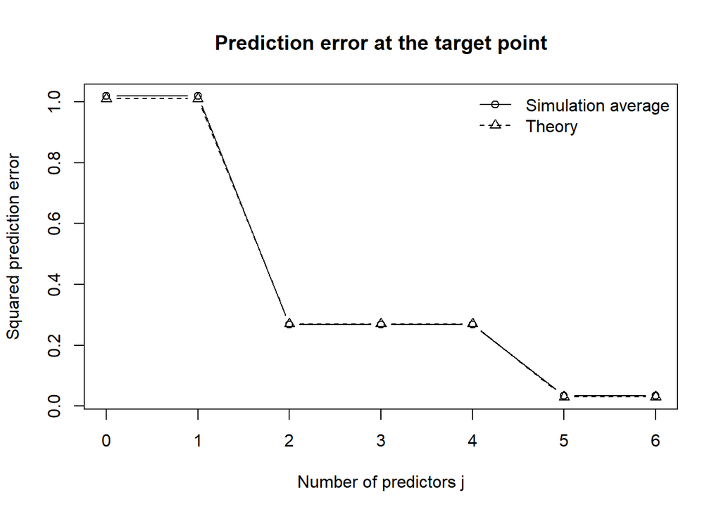

```r
plot(
  0:q, avg_squared_error,
  type = "b", pch = 1, lty = 1,
  ylim = range(avg_squared_error, theory_q2),
  xlab = "Number of predictors j",
  ylab = "Squared prediction error",
  main = "Prediction error at the target point"
)
lines(0:q, theory_q2, type = "b", pch = 2, lty = 2)
legend(
  "topright",
  legend = c("Simulation average", "Theory"),
  lty = c(1, 2),
  pch = c(1, 2),
  bty = "n"
)
```

**Show the R code**

```r
cat(
  "Smallest j minimizing theoretical error:",
  which.min(theory_q2) - 1,
  "\n"
)
```

```
Smallest j minimizing theoretical error: 5
```

The first minimum occurs at 5 predictors. The 6-predictor model has the same theoretical error, so adding the last predictor does not improve prediction at this particular target point.

### c. Why only predictors 2 and 5 matter directly

All six coefficients are nonzero, but that does not mean all six variables contribute to this one prediction. At this target point, coordinates 1, 3, 4, and 6 are zero, so their contribution to the target mean is zero. Predictors 2 and 5 each contribute 0.5.

This is specific to the chosen target point. A variable whose value is zero here can still matter for prediction at other rows of the design matrix, so the model that is best at this point does not have to be the model with the best average prediction error.

## Question 3: The optimism correction

### a. Derivation

For training error,

$$(\mathbf I_n-\mathbf H)\mathbf y
=
(\mathbf I_n-\mathbf H)\boldsymbol\mu
+
(\mathbf I_n-\mathbf H)\boldsymbol\epsilon.$$

The cross term has expectation zero, so

$$\mathbb{E}\!\left[
\left\lVert
(\mathbf I_n-\mathbf H)\mathbf y
\right\rVert_2^2
\mid \mathbf X
\right]
=
B^2
+
\sigma^2\operatorname{tr}\!\left((\mathbf I_n-\mathbf H)^2\right).$$

Since the hat matrix is symmetric and idempotent,

$$(\mathbf I_n-\mathbf H)^2
=
\mathbf I_n-\mathbf H,$$

and therefore

$$\operatorname{tr}(\mathbf I_n-\mathbf H)
=
n-p.$$

Thus,

$$\mathbb{E}\!\left(
\operatorname{MSE}_{\mathrm{train}}
\mid \mathbf X
\right)
=
\frac{B^2}{n}
+
\sigma^2\left(1-\frac{p}{n}\right).$$

For an independent test response,

$$\mathbf y^*-\mathbf H\mathbf y
=
(\mathbf I_n-\mathbf H)\boldsymbol\mu
+
\boldsymbol\epsilon^*
-
\mathbf H\boldsymbol\epsilon.$$

The two noise vectors are independent, so the cross terms have expectation zero. Also,

$$\mathbb{E}\!\left(
\lVert\boldsymbol\epsilon^*\rVert_2^2
\mid \mathbf X
\right)
=
n\sigma^2$$

and

$$\mathbb{E}\!\left(
\lVert\mathbf H\boldsymbol\epsilon\rVert_2^2
\mid \mathbf X
\right)
=
\sigma^2\operatorname{tr}(\mathbf H)
=
p\sigma^2.$$

Therefore,

$$\mathbb{E}\!\left(
\operatorname{MSE}_{\mathrm{test}}
\mid \mathbf X
\right)
=
\frac{B^2}{n}
+
\sigma^2\left(1+\frac{p}{n}\right).$$

### b. Expected optimism

Subtracting the training expectation from the test expectation gives

$$\mathbb{E}\!\left(
\operatorname{MSE}_{\mathrm{test}}
-
\operatorname{MSE}_{\mathrm{train}}
\mid \mathbf X
\right)
=
\frac{2p\sigma^2}{n}.$$

For the values in the question:

**Show the R code**

```r
n <- 120
p <- 5
bias_mean_sq <- 0.04
sigma2 <- 1

expected_train <- bias_mean_sq + sigma2 * (1 - p / n)
expected_test <- bias_mean_sq + sigma2 * (1 + p / n)
optimism <- expected_test - expected_train

c(
  expected_train = expected_train,
  expected_test = expected_test,
  difference = optimism
)
```

```
expected_train  expected_test     difference
    0.99833333     1.08166667     0.08333333
```

This gives

$$\mathbb{E}\!\left(
\operatorname{MSE}_{\mathrm{train}}
\mid \mathbf X
\right)
\approx
0.9983,$$

$$\mathbb{E}\!\left(
\operatorname{MSE}_{\mathrm{test}}
\mid \mathbf X
\right)
\approx
1.0817,$$

and

$$\mathbb{E}\!\left(
\operatorname{MSE}_{\mathrm{test}}
-
\operatorname{MSE}_{\mathrm{train}}
\mid \mathbf X
\right)
\approx
0.0833.$$

These are expected values. In a single random run it is still possible for the observed test MSE to come out below the observed training MSE.

### c. Corrected test MSE and Mallows’ criterion

**Show the R code**

```r
n <- 120
p <- 5
RSS <- 116.4
sigma2_hat <- 0.96

mse_test_hat <- (RSS + 2 * p * sigma2_hat) / n
Cp <- RSS / sigma2_hat - n + 2 * p

c(
  corrected_test_MSE = mse_test_hat,
  Cp = Cp
)
```

```
corrected_test_MSE                 Cp
              1.05              11.25
```

The two values are

$$\widehat{\operatorname{MSE}}_{\mathrm{test}}
=
1.05$$

and

$$C_p
=
11.25.$$

Starting from Mallows' criterion,

$$C_p+n
=
\frac{\operatorname{RSS}}{\widehat{\sigma}^2}
+2p.$$

Multiplying by the common variance estimate and dividing by the common sample size gives

$$\widehat{\operatorname{MSE}}_{\mathrm{test}}
=
\widehat{\sigma}^2
\left(
1+\frac{C_p}{n}
\right).$$

So when the candidate models use the same sample size and the same variance estimate, minimizing Mallows' criterion gives the same ordering as minimizing this corrected test MSE.

## Question 4: Comparing Mallows’ criterion, AIC, and BIC

### a. Fit the models

**Show the R code**

```r
diabetes <- read.csv("diabetes.csv")
train <- diabetes[1:370, ]

vars_A <- c("bmi", "bp", "s5", "sex", "s1", "s2", "s4")
vars_B <- c(vars_A, "s6")
vars_full <- c(
  "age", "sex", "bmi", "bp", "s1",
  "s2", "s3", "s4", "s5", "s6"
)

fit_A <- lm(reformulate(vars_A, response = "y"), data = train)
fit_B <- lm(reformulate(vars_B, response = "y"), data = train)
fit_full <- lm(reformulate(vars_full, response = "y"), data = train)

RSS_A <- sum(resid(fit_A)^2)
RSS_B <- sum(resid(fit_B)^2)
RSS_full <- sum(resid(fit_full)^2)

p_A <- length(coef(fit_A))
p_B <- length(coef(fit_B))
p_full <- length(coef(fit_full))

df_full <- df.residual(fit_full)
sigma2_full <- RSS_full / df_full

model_fit <- data.frame(
  model = c("A", "B", "Full"),
  p = c(p_A, p_B, p_full),
  RSS = round(c(RSS_A, RSS_B, RSS_full), 3)
)

model_fit
cat("Full-model residual df:", df_full, "\n")
cat("Full-model variance estimate:", round(sigma2_full, 3), "\n")
```

```
  model  p     RSS
1     A  8 1098909
2     B  9 1089717
3  Full 11 1089452
```

**Show the R code**

```r
cat("Full-model residual df:", df_full, "\n")
```

```
Full-model residual df: 359
```

**Show the R code**

```r
cat("Full-model variance estimate:", round(sigma2_full, 3), "\n")
```

```
Full-model variance estimate: 3034.684
```

The fitted RSS values are about 1,098,908.566 for Model A, 1,089,717.057 for Model B, and 1,089,451.721 for the full model. The full model has 359 residual degrees of freedom, so the common variance estimate is

$$\widehat{\sigma}_{\mathrm{full}}^2
\approx
3034.684.$$

### b. Model-selection criteria

**Show the R code**

```r
n <- 370

Cp_A <- RSS_A / sigma2_full - n + 2 * p_A
Cp_B <- RSS_B / sigma2_full - n + 2 * p_B

AIC_A <- n * log(RSS_A / n) + 2 * p_A
AIC_B <- n * log(RSS_B / n) + 2 * p_B

BIC_A <- n * log(RSS_A / n) + p_A * log(n)
BIC_B <- n * log(RSS_B / n) + p_B * log(n)

criteria <- data.frame(
  model = c("A", "B"),
  Cp = round(c(Cp_A, Cp_B), 3),
  AIC_reduced = round(c(AIC_A, AIC_B), 3),
  BIC_reduced = round(c(BIC_A, BIC_B), 3)
)

criteria
```

```
  model    Cp AIC_reduced BIC_reduced
1     A 8.116    2974.640    3005.948
2     B 7.087    2973.532    3008.754
```

The approximate values are:

| Model | Mallows criterion | Reduced AIC | Reduced BIC |
| --- | --- | --- | --- |
| A | 8.116 | 2974.640 | 3005.948 |
| B | 7.087 | 2973.532 | 3008.754 |

Mallows' criterion and reduced AIC both choose Model B, while reduced BIC chooses Model A.

### c. Why the criteria disagree

The difference comes from how strongly each criterion penalizes the extra variable. Adding s6 lowers RSS by about 9191.509. For Mallows' criterion, the scaled improvement in fit is about 3.029, while the penalty for one extra parameter is 2. Since the improvement is larger than the penalty, Model B has the smaller criterion value.

AIC gives the same decision. The improvement in its log-RSS term is about 3.108, which is again larger than the penalty of 2.

BIC uses a larger one-parameter penalty:

$$\log(370)
\approx
5.914.$$

Since 5.914 is larger than the 3.108 improvement in fit, BIC stays with Model A.

## Question 5: Validation and final test data

### a. Where the proposed procedure goes wrong

The problem starts in step 3, when the final test MSE is used to choose among the eleven models. Once that happens, the test set is no longer an untouched final evaluation set.

Taking the smallest of eleven test errors also makes the reported value look better than it should. Even if the models have similar true prediction error, random variation can make one of them look unusually good on this particular test set.

### b. Five-fold cross-validation inside the training data

I would choose the predictor count using only rows 1 through 370. The fixed seed is only there so that the same five folds are used if the code is run again.

**Show the R code**

```r
set.seed(43205)

train <- diabetes[1:370, ]
final_test <- diabetes[371:442, ]

predictor_order <- c(
  "age", "sex", "bmi", "bp", "s1",
  "s2", "s3", "s4", "s5", "s6"
)

K <- 5
fold_id <- sample(rep(1:K, length.out = nrow(train)))
cv_mse <- numeric(11)

for (j in 0:10) {
  vars <- predictor_order[seq_len(j)]
  fold_mse <- numeric(K)

  for (f in 1:K) {
    fold_train <- train[fold_id != f, ]
    fold_valid <- train[fold_id == f, ]

    form <- if (j == 0) {
      y ~ 1
    } else {
      reformulate(vars, response = "y")
    }

    fit <- lm(form, data = fold_train)
    pred <- predict(fit, newdata = fold_valid)
    fold_mse[f] <- mean((fold_valid$y - pred)^2)
  }

  cv_mse[j + 1] <- mean(fold_mse)
}

cv_results <- data.frame(
  predictors = 0:10,
  CV_MSE = round(cv_mse, 3)
)

cv_results

best_j <- which.min(cv_mse) - 1
cat("Selected predictor count:", best_j, "\n")
```

```
   predictors   CV_MSE
1           0 5960.940
2           1 5809.291
3           2 5858.935
4           3 3989.397
5           4 3748.975
6           5 3789.129
7           6 3799.011
8           7 3198.290
9           8 3214.378
10          9 3104.117
11         10 3132.714
```

**Show the R code**

```r
best_j <- which.min(cv_mse) - 1
cat("Selected predictor count:", best_j, "\n")
```

```
Selected predictor count: 9
```

After selecting the predictor count, I refit that model on all 370 training observations and use the final test set once.

**Show the R code**

```r
selected_vars <- predictor_order[seq_len(best_j)]

final_formula <- if (best_j == 0) {
  y ~ 1
} else {
  reformulate(selected_vars, response = "y")
}

final_fit <- lm(final_formula, data = train)
final_pred <- predict(final_fit, newdata = final_test)
final_test_mse <- mean((final_test$y - final_pred)^2)

cat("Final test MSE:", round(final_test_mse, 3), "\n")
```

```
Final test MSE: 2369.344
```

This way, the cross-validation step handles model selection and the final test set is kept separate until the end.

### c. If the test set has already been examined

If the test set has already been used to compare the eleven models, I can still report those results, but I would not call the minimum a clean estimate of future prediction error. It is now part of the model-selection process.

For a genuinely final evaluation, I would need another set of observations that was not used while choosing the model.

## Reference

James, Witten, Hastie, Tibshirani, and Taylor, *An Introduction to Statistical Learning*, Chapters 3, 5, and 6.